# R Notebook

```r
library(readr)
library(Stat2Data)
library(car)
source("ShowSubsets.R")
source("HistNormal.R")
library(corrplot)
library(leaps)
library(tidyverse)
library(dplyr)
library(mosaic)

Student.Alc <- read_csv("student-mat.csv")
Student.Alc
```

| school | sex | age | address | famsize | Pstatus | Medu | Fedu | Mjob | Fjob | reason | guardian | traveltime | studytime | failures | schoolsup | famsup | paid | activities | nursery | higher | internet | romantic | famrel | freetime | goout | Dalc | Walc | health | absences | … |
| --- | --- | --- | --- | --- | --- | --- | --- | --- | --- | --- | --- | --- | --- | --- | --- | --- | --- | --- | --- | --- | --- | --- | --- | --- | --- | --- | --- | --- | --- | --- |
| GP | F | 18 | U | GT3 | A | 4 | 4 | at_home | teacher | course | mother | 2 | 2 | 0 | yes | no | no | no | yes | yes | no | no | 4 | 3 | 4 | 1 | 1 | 3 | 6 | … |
| GP | F | 17 | U | GT3 | T | 1 | 1 | at_home | other | course | father | 1 | 2 | 0 | no | yes | no | no | no | yes | yes | no | 5 | 3 | 3 | 1 | 1 | 3 | 4 | … |
| GP | F | 15 | U | LE3 | T | 1 | 1 | at_home | other | other | mother | 1 | 2 | 3 | yes | no | yes | no | yes | yes | yes | no | 4 | 3 | 2 | 2 | 3 | 3 | 10 | … |
| GP | F | 15 | U | GT3 | T | 4 | 2 | health | services | home | mother | 1 | 3 | 0 | no | yes | yes | yes | yes | yes | yes | yes | 3 | 2 | 2 | 1 | 1 | 5 | 2 | … |
| GP | F | 16 | U | GT3 | T | 3 | 3 | other | other | home | father | 1 | 2 | 0 | no | yes | yes | no | yes | yes | no | no | 4 | 3 | 2 | 1 | 2 | 5 | 4 | … |
| GP | M | 16 | U | LE3 | T | 4 | 3 | services | other | reputation | mother | 1 | 2 | 0 | no | yes | yes | yes | yes | yes | yes | no | 5 | 4 | 2 | 1 | 2 | 5 | 10 | … |
| GP | M | 16 | U | LE3 | T | 2 | 2 | other | other | home | mother | 1 | 2 | 0 | no | no | no | no | yes | yes | yes | no | 4 | 4 | 4 | 1 | 1 | 3 | 0 | … |
| GP | F | 17 | U | GT3 | A | 4 | 4 | other | teacher | home | mother | 2 | 2 | 0 | yes | yes | no | no | yes | yes | no | no | 4 | 1 | 4 | 1 | 1 | 1 | 6 | … |
| GP | M | 15 | U | LE3 | A | 3 | 2 | services | other | home | mother | 1 | 2 | 0 | no | yes | yes | no | yes | yes | yes | no | 4 | 2 | 2 | 1 | 1 | 1 | 0 | … |
| GP | M | 15 | U | GT3 | T | 3 | 4 | other | other | home | mother | 1 | 2 | 0 | no | yes | yes | yes | yes | yes | yes | no | 5 | 5 | 1 | 1 | 1 | 5 | 0 | … |

[output cut: 385 more lines]

**Part 1: Data Preparation** For HW 6 we chose to go a dataset on student’s alcohol consumption data.

[Student Alcohol Consumption](https://data.world/data-society/student-alcohol-consumption)

```r
Stu.Alc <- Student.Alc %>%
  select(sex, age, studytime, Dalc, Walc, health, absences)
Stu.Alc
```

| sex | age | studytime | Dalc | Walc | health | absences |
| --- | --- | --- | --- | --- | --- | --- |
| F | 18 | 2 | 1 | 1 | 3 | 6 |
| F | 17 | 2 | 1 | 1 | 3 | 4 |
| F | 15 | 2 | 2 | 3 | 3 | 10 |
| F | 15 | 3 | 1 | 1 | 5 | 2 |
| F | 16 | 2 | 1 | 2 | 5 | 4 |
| M | 16 | 2 | 1 | 2 | 5 | 10 |
| M | 16 | 2 | 1 | 1 | 3 | 0 |
| F | 17 | 2 | 1 | 1 | 1 | 6 |
| M | 15 | 2 | 1 | 1 | 1 | 0 |
| M | 15 | 2 | 1 | 1 | 5 | 0 |

[output cut: 385 more lines]

There are 33 variables in the original dataset, but for our purposes we only need a few. We chose to include the follwoing varibales in a subset dataset of the original dataset: sex, age, studytime, Dalc, Walc, health, absences.

1. sex - student’s sex (binary: ‘F’ - female or ‘M’ - male)
2. age - student’s age (numeric: from 15 to 22)
3. studytime - weekly study time (numeric: 1 - <2 hours, 2 - 2 to 5 hours, 3 - 5 to 10 hours, or 4 - >10 hours)
4. Dalc - workday alcohol consumption (numeric: from 1 - very low to 5 - very high)
5. Walc - weekend alcohol consumption (numeric: from 1 - very low to 5 - very high)
6. health - current health status (numeric: from 1 - very bad to 5 - very good)
7. absences - number of school absences (numeric: from 0 to 93)

```r
Stu.Alc <- Stu.Alc %>%
  mutate(`sex`=ifelse(sex=="F",0,1))
Stu.Alc
```

| sex | age | studytime | Dalc | Walc | health | absences |
| --- | --- | --- | --- | --- | --- | --- |
| 0 | 18 | 2 | 1 | 1 | 3 | 6 |
| 0 | 17 | 2 | 1 | 1 | 3 | 4 |
| 0 | 15 | 2 | 2 | 3 | 3 | 10 |
| 0 | 15 | 3 | 1 | 1 | 5 | 2 |
| 0 | 16 | 2 | 1 | 2 | 5 | 4 |
| 1 | 16 | 2 | 1 | 2 | 5 | 10 |
| 1 | 16 | 2 | 1 | 1 | 3 | 0 |
| 0 | 17 | 2 | 1 | 1 | 1 | 6 |
| 1 | 15 | 2 | 1 | 1 | 1 | 0 |
| 1 | 15 | 2 | 1 | 1 | 5 | 0 |

[output cut: 385 more lines]

Here if sex = 0 then the student is female and if sex = 1 the student is male

**Part 2: Single Predictor**

```r
#1
LogReg.mod1 <- glm(sex~studytime, family = binomial, data = Stu.Alc)
summary(LogReg.mod1)
```

```
##
## Call:
## glm(formula = sex ~ studytime, family = binomial, data = Stu.Alc)
##
## Deviance Residuals:
##     Min       1Q   Median       3Q      Max
## -1.4929  -1.1342  -0.5684   1.2213   1.9508
##
## Coefficients:
##             Estimate Std. Error z value Pr(>|z|)
## (Intercept)   1.5362     0.2975   5.163 2.43e-07 ***
## studytime    -0.8194     0.1414  -5.793 6.92e-09 ***
## ---
## Signif. codes:  0 '***' 0.001 '**' 0.01 '*' 0.05 '.' 0.1 ' ' 1
##
## (Dispersion parameter for binomial family taken to be 1)
##
##     Null deviance: 546.47  on 394  degrees of freedom
## Residual deviance: 507.24  on 393  degrees of freedom
## AIC: 511.24
##
## Number of Fisher Scoring iterations: 4
```

```r
logit = function(B0, B1, x) {
    exp(B0+B1*x)/(1+exp(B0+B1*x))
  }
```

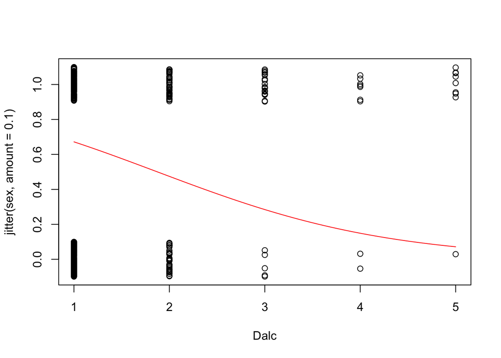

```r
#2
B0 <- summary(LogReg.mod1)$coef[1]
B1 <- summary(LogReg.mod1)$coef[2]

plot(jitter(sex,amount=0.1)~Dalc,data=Stu.Alc)
curve(logit(B0, B1, x),add=TRUE, col="red")
```